# NTOLab11

Ethan Schacht, Anderson Mun, Ryan Tate, Arie del Valle, David Orozco

4/2/2019

### Individual Sections

#### Ethan’s Section

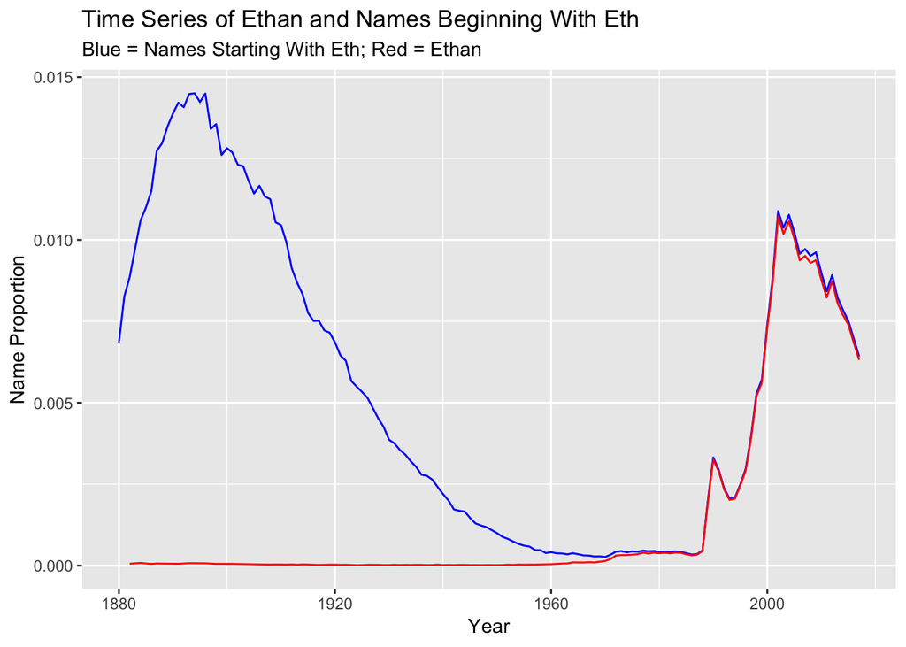

- My name was becoming incredibly popular when I was born in 1999, and it still makes up nearly all of the names starting with “Eth”. However, the name has been declining since 2002 when it hit its peak at a proportion of 0.0107. In 2017, the proportion of “Eth” names was 0.0064 and the proportion of “Ethan” was 0.0063. This means that 98.4% of all names starting with “Eth” are “Ethan”. My name appeared to begin rapidly gain popularity around the 1990’s.

#### Arie’s Section

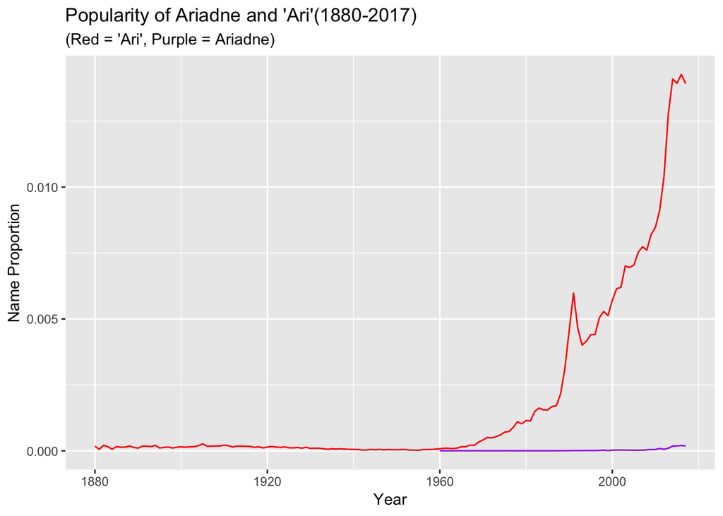

- I used the regular expression `^Ariadne$` to look for my name. My name now is more popular now compared to when I was born. In the graph you can see a slight increase after 1996. My name is very unpopular now compared to the names that start with “Ari”. Represented in the graph, you can see a large difference in proportions between the red line and purple line.

#### David’s Section

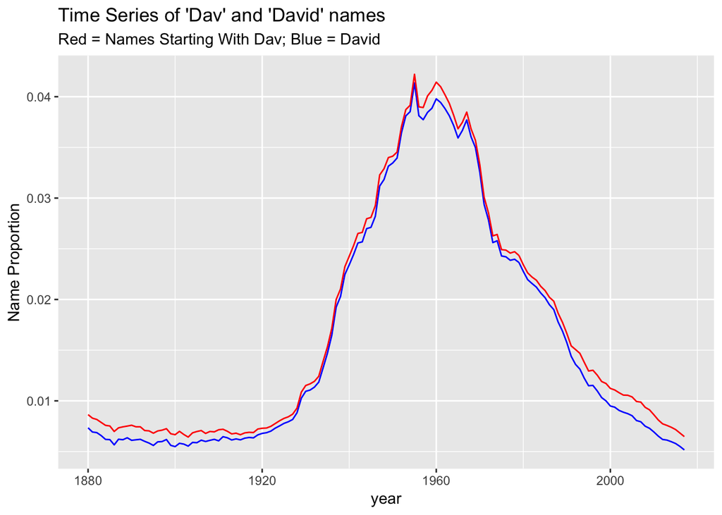

- The time series of all the names that begin with ‘Dav’ hug the time series of ‘David’ name very closely. This means that the popularity of names that begin with ‘Dav’ is due to the popularity of the name ‘David’. As more people were named ‘David’ variations of ‘David’ were created but never became a unique and prominent name. I used `str_detect()` and the regular expressions `^Dav` and `^[D]avi[d]$` to look for the names.
- The popularity of ‘David’ was the highest around the 1960s. I was born in 1999 during a decline in ‘David’ popularity. Personally this makes sense, I have not met many people my age named ‘David’ but I have met plenty of middle aged people names ‘David’.

#### Anderson’s Section

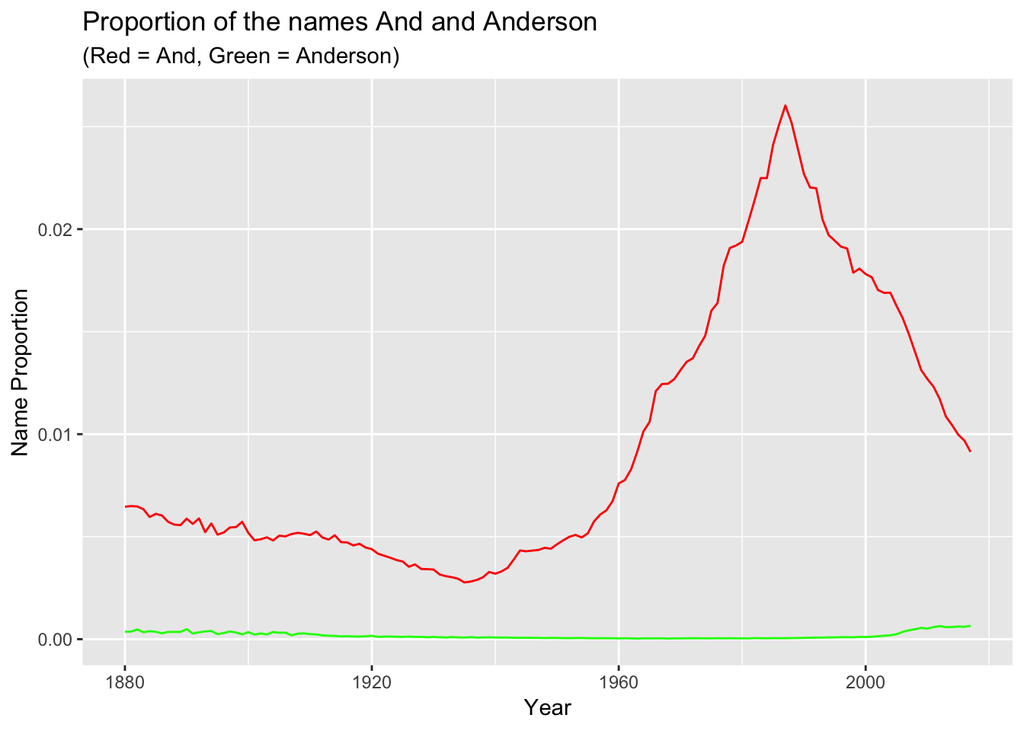

#### Ryan’s Section

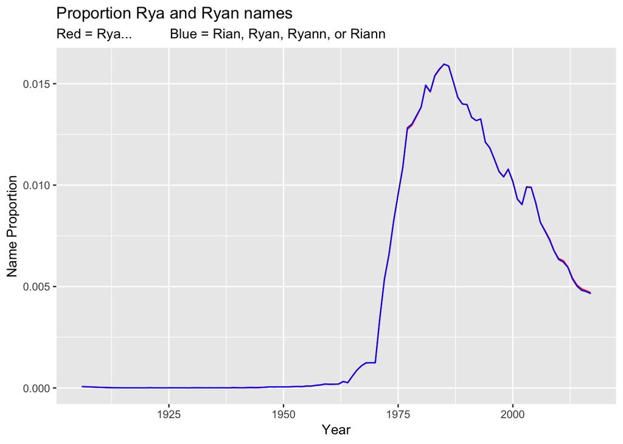

- The regular expressions I used to find most variations of Ryan spellings `(^R[yi]an$)|(^R[yi]ann$)` found when a name was Rian, Riann, Ryan, or Ryann. I was satisfied with this regex becuase the proportion of those names was very close to the proportion of names starting with Rya. This is probably because not a lot of names start with Rya and are not spelled Ryan or Ryann.
- My name now is not as popular as it was when I was born, but its popularity ahd been going down since 1985 so I am not that shaken.
- My name is slightly less popular (.00465 compared to .00470) so I am not that tilted. However, it is very very close and could be the result of my regex not finding all variations of the name Ryan, or I not knowing all the variations. In any case, it should be noted that as the proportions are so close we can probably say that there is no significant difference in the popularity of my name and other names that start with Rya.

### Team Sections

#### Ariel / Rachel Regex

```
## # A tibble: 58 x 5
##     year sex   name         n       prop
##    <dbl> <chr> <chr>    <int>      <dbl>
##  1  1973 F     Ariel       43 0.0000277
##  2  1973 F     Ariella     14 0.00000901
##  3  1973 F     Arielle      9 0.00000579
##  4  1973 F     Rachal      24 0.0000154
##  5  1973 F     Rachel    6106 0.00393
##  6  1973 F     Rachele     95 0.0000611
##  7  1973 F     Rachell     53 0.0000341
##  8  1973 F     Rachella     6 0.00000386
##  9  1973 F     Rachelle   883 0.000568
## 10  1988 F     Arial       12 0.00000624
## # … with 48 more rows
```

```
## # A tibble: 4 x 2
##    year    prop
##   <dbl>   <dbl>
## 1  1973 0.00465
## 2  1988 0.00948
## 3  1990 0.0109
## 4  2017 0.00324
```

- The first tibble displays various versions of the female names similar to “Ariel” and “Rachel” in 1973, 1988, 1990, 2017, arranged accordingly. There were 7 versions of “Ariel” and 9 versions of “Rachel” in 1988, for example.
- The second tibble displays the probabilities of versions of the names “Ariel” or “Rachel” occuring out of all names in the given years. The year where Ariel or Rachel (or any versions) appear the most popular is 1990 at 0.01.

#### The Little Mermaid Effect

```
## [1] 0.9987013
```

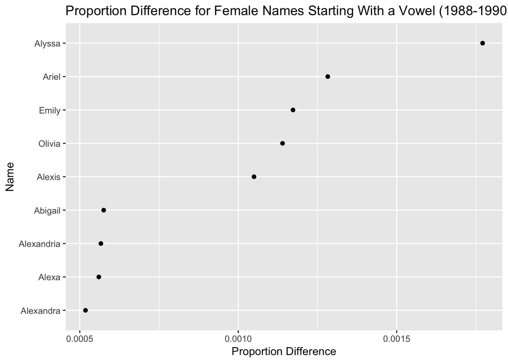

- Findings: There is a significant difference in the change in proportion of “Ariel” names compared to the change in proportion of names starting with a vowel from 1988 to 1990. Ariel was in the 99.9 percentile for this change with a difference of 0.00128231, only behind “Alyssa”. This graph shows the most increasingly popular names from 1988 to 1990 in the order of greatest proportion difference.

#### Names Team Section

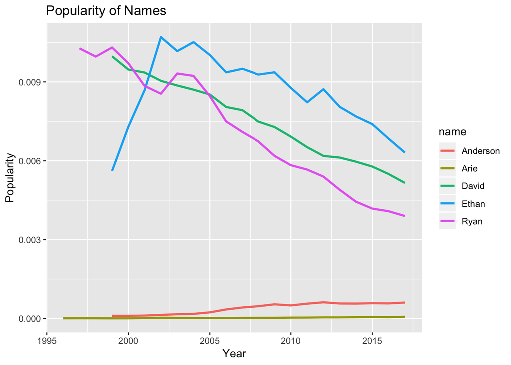

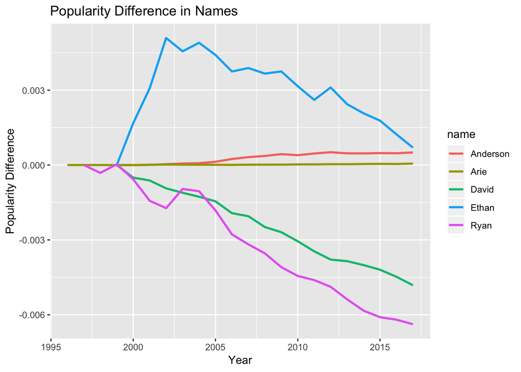

- The first graph shows the how the popularity of the names change after the birth year. Ethan, Ryan, and David names were the most popular, and Anderson and Aries where the least popular.
- The second graph shows the popularity difference from the year of birth. For example: If born in 1999, the popularity differnce for 2005 is (popularity in 2005-popularity in 1999). The graph shows the popularity change trends for all names in respect to thier birth year.
- Ethan’s name seems to have gained the more popularity in the years after his birth. However, it seems to be returning to its orginal popularity(Popularity difference = 0 is orginal popularity at birth).
- Anderson’s name shows a slight but constant increase in popularity.
- Because Arie’s name is the least popular, it makes sense that there is not a disctict trend. However, the date shows a very slight increase in her name’s popularity.
- Both Ryan and David show a steady and steep decrease in popularity compared to their birth year.

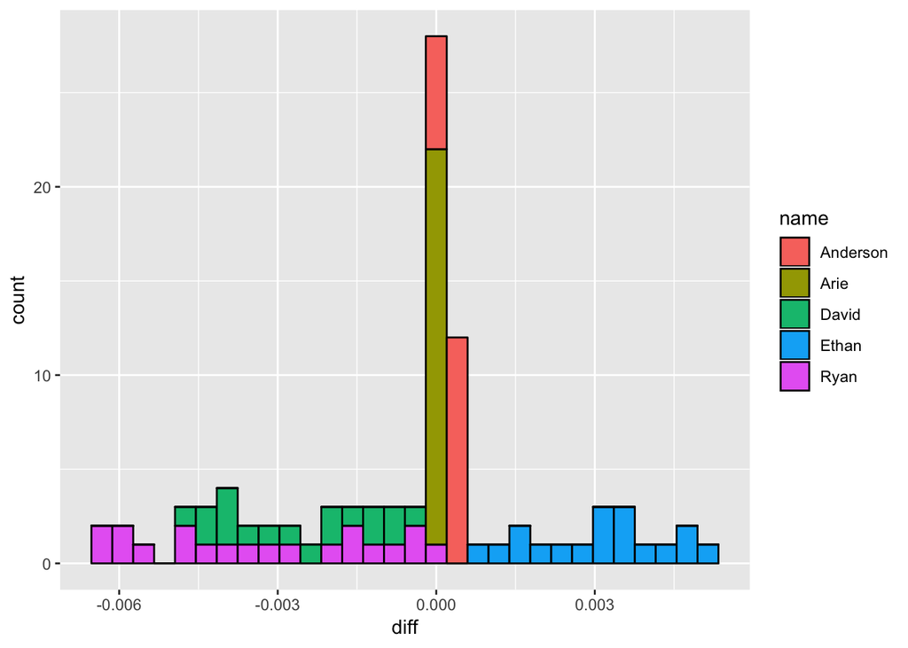

```
## # A tibble: 5 x 2
##   name      max_diff
##   <chr>        <dbl>
## 1 Anderson 0.000514
## 2 Arie     0.0000583
## 3 David    0.00482
## 4 Ethan    0.00509
## 5 Ryan     0.00638
```

- Explanation: This histogram displays the distribution of the difference in proportions. The names Anderson and Arie display little to no change in proptions since the distribution stays in the middle. This makes sense because these names were the least popular compared to the others. The names David, Ethan, and Ryan show much more variation since the distribution of those names are more spread apart. Daivd and Ryan show a negative decrease in difference, where as Ethan shows the opposite. This makes sense because the names David and Ryan show a decrease in popularity, while the name Ethan has increased in popularity. The tibble above shows that the name Ryan has the greatest difference over the years.

#### Who Did What

Ethan- Ariel/Rachel Regexs, worked on Little Mermaid and made graph, individual section.

Anderson- Individual section

David- Created the ‘Popularity of Names’ tibble and graph. Individual section. Editing.

Ryan- Individual section

Arie- calcualted percentile for Little Mermaid(with help of David and Ethan), wrote explanation for you names sectoin,ind section